# Processing, Wrangling, and Visualizing Data

## Pandas

- In data analysis, the requirement is to store series or tabular data
- This can be done using lists -> inefficient
  - python lists store the data using pointers and python objects, which is quite inefficient in terms of memory and performance
- Pandas has custom data structures to store and process the data effectively

### Pandas data structures

- Series
  - one dimensional indexed/labeled array that can be created using Series() function by passing an object of list/dictionary/array as a parameter to Series() function
  - you can only store one attribute per index
- Dataframes
  - most important and useful data structure, used for all kind of datarepresentation and manipulation in pandas
  - can contain heterogenous data
  - typically tabular data similar to excel or SQL or TAbles in Matlab

### Pandas reference

- https://pandas.pydata.org/docs/reference/frame.html#

## Pandas Series

```python
# import module pandas and give it a shortcut pd
import pandas as pd
import numpy as np
```

```python
# difference between values and indices in Pandas Series
l1 = [5555, 7000, 1980] # list of revenues
revenues = pd.Series(l1) # create Pandas Series from l1

print(revenues)
```

```
0    5555
1    7000
2    1980
dtype: int64
```

```python
# how to get values and index of the series
print(revenues.values)
print(revenues.index)
```

```
[5555 7000 1980]
RangeIndex(start=0, stop=3, step=1)
```

```python
# Index can be customized by passing a list to index property
# Create Series using list of values and index property
city_revenues = pd.Series(
    [4200, 8000, 6500],
    index=["Amsterdam", "Toronto", "Tokyo"])
city_revenues
```

```
Amsterdam    4200
Toronto      8000
Tokyo        6500
dtype: int64
```

```python
# create series from a dictionary, where keys are taken to be indices in the Series
city_employee_count = pd.Series({"Amsterdam": 5, "Tokyo": 8})
city_employee_count
```

```
Amsterdam    5
Tokyo        8
dtype: int64
```

## Pandas Dataframes

- DataFrame stores the data in tabular form
- DataFrame is a two-dimensional data structure that organizes the data into rows and columns
- A dataFrame can be created using lists, dictionaries, numpy arrays or series

```python
# create dataframe
df = pd.DataFrame() # empty dataframe

# using list
my_data=[['e-book', 2000], ['plants', 6000], ['Pencil', 3000]] # 2d list, similar to 2d array
print(my_data)
indexes=[1,2,3]
columns_name=['product', 'unit_sold']
product_df = pd.DataFrame(data=my_data, index=indexes, columns=columns_name)
print(product_df)

# using dictionaries
data={'product': ['e-book', 'plants', 'Pencil'], 'unit_sold': [2000, 5000, 3000]}
product_df = pd.DataFrame(data=data)
print(product_df)

# using numpy array
products = np.array([['','product','unit_sold'], [1, 'E-book', 2000],[2, 'Plants', 6000], [3, 'Pencil', 3000]])
# print(products)
product_pf = pd.DataFrame(data=products[1:,1:], # [1:,1:] from first row till end, from first column till end
                          index=products[1:,0], # [1:,0] from first row till end, only first column
                          columns=products[0,1:]) # [1:,0] only first row, form first column till end
print(product_pf) # output is same as of first case

# using combination of series objects into a DataFrame by providing a dictionary in the constructor
# the dictionary keys will become the column names, and the values should contain the Series objects
# use series from above examples
city_data = pd.DataFrame({"revenue": city_revenues, "employee_count": city_employee_count})
print(city_data)
```

```
[['e-book', 2000], ['plants', 6000], ['Pencil', 3000]]
  product  unit_sold
1  e-book       2000
2  plants       6000
3  Pencil       3000
  product  unit_sold
0  e-book       2000
1  plants       5000
2  Pencil       3000
  product unit_sold
1  E-book      2000
2  Plants      6000
3  Pencil      3000
           revenue  employee_count
Amsterdam     4200             5.0
Tokyo         6500             8.0
Toronto       8000             NaN
```

```python
# instead on print, get better looking output in interactive console
city_data
```

|  | revenue | employee_count |
| --- | --- | --- |
| Amsterdam | 4200 | 5.0 |
| Tokyo | 6500 | 8.0 |
| Toronto | 8000 | NaN |

```python
# show and access labels, indices and values

# row index - first column (indexing from 0 - so 0th column)
print(city_data.axes[0])
print(city_data.index)

# columns name (labels)
print(city_data.axes[1])
print(city_data.columns)
print(city_data.keys())

# values
print(city_data.values)
```

```
Index(['Amsterdam', 'Tokyo', 'Toronto'], dtype='object')
Index(['Amsterdam', 'Tokyo', 'Toronto'], dtype='object')
Index(['revenue', 'employee_count'], dtype='object')
Index(['revenue', 'employee_count'], dtype='object')
Index(['revenue', 'employee_count'], dtype='object')
[[4.2e+03 5.0e+00]
 [6.5e+03 8.0e+00]
 [8.0e+03     nan]]
```

```python
# get a given column
city_data['revenue']
```

```
Amsterdam    4200
Tokyo        6500
Toronto      8000
Name: revenue, dtype: int64
```

```python
a = city_data.loc['Amsterdam']
print(type(a))
b = city_data.loc[['Amsterdam']]
print(type(b))
```

```
<class 'pandas.core.series.Series'>
<class 'pandas.core.frame.DataFrame'>
```

```python
a
```

```
revenue           4200.0
employee_count       5.0
Name: Amsterdam, dtype: float64
```

```python
b
```

|  | revenue | employee_count |
| --- | --- | --- |
| Amsterdam | 4200 | 5.0 |

## Numpy

- Numpy is the core library for scientific computing in Python. It provides a high-performance multidimensional array object, and tools for working with these arrays

#### Numpy Arrays

- A numpy array is a grid of values, all of the same type, and is indexed by a tuple of nonnegative integers
- The number of dimensions is the rank of the array; the shape of an array is a tuple of integers giving the size of the array along each dimension.
- We can initialize numpy arrays from nested Python lists, and access elements using square brackets
  - nested lists: https://www.learnbyexample.org/python-nested-list/
- numpy details at https://numpy.org/doc/stable/user/quickstart.html

## Data retrieval

- List of dictionaries
- CSV files
- Web scraping
- Databases - online, sql

### List of dictionaries

```python
# List of dictionaries
my_list = [{'car': 'Toyota', 'price per day': 50, 'milage': 4852, 'color':'black'},
           {'car': 'VW', 'price per day': 70, 'milage': 123, 'color':'white'},
           {'car': 'BMW', 'price per day': 65, 'milage': 2548, 'color':'black'}]
df = pd.DataFrame(my_list)
print(df)
df
```

```
      car  price per day  milage  color
0  Toyota             50    4852  black
1      VW             70     123  white
2     BMW             65    2548  black
```

|  | car | price per day | milage | color |
| --- | --- | --- | --- | --- |
| 0 | Toyota | 50 | 4852 | black |
| 1 | VW | 70 | 123 | white |
| 2 | BMW | 65 | 2548 | black |

```python
# dictionary to dataframe
my_dict = {'car': ['Toyota', 'VW', 'BMW'],
           'price per day': [50, 65, 70],
           'milage': [4852, 123, 2548],
           'color':['black', 'white', 'black']}
df = pd.DataFrame.from_dict(my_dict)
print(df)
df
```

```
      car  price per day  milage  color
0  Toyota             50    4852  black
1      VW             65     123  white
2     BMW             70    2548  black
```

|  | car | price per day | milage | color |
| --- | --- | --- | --- | --- |
| 0 | Toyota | 50 | 4852 | black |
| 1 | VW | 65 | 123 | white |
| 2 | BMW | 70 | 2548 | black |

```python
# check dtyps of pandas
print(df.dtypes)
```

```
car              object
price per day     int64
milage            int64
color            object
dtype: object
```

```python
d = df.to_dict()
d
```

```
{'car': {0: 'Toyota', 1: 'VW', 2: 'BMW'},
 'price per day': {0: 50, 1: 65, 2: 70},
 'milage': {0: 4852, 1: 123, 2: 2548},
 'color': {0: 'black', 1: 'white', 2: 'black'}}
```

```python
s = df.to_string()
# notice the difference
print(s)
s #notice \n
```

```
      car  price per day  milage  color
0  Toyota             50    4852  black
1      VW             65     123  white
2     BMW             70    2548  black
```

```
'      car  price per day  milage  color\n0  Toyota             50    4852  black\n1      VW             65     123  white\n2     BMW             70    2548  black'
```

### CSV files

```python
# when using gdrive to load and store data, we need to mount it
from google.colab import drive
drive.mount('/content/gdrive')
```

```python
ls
```

```
gdrive/  sample_data/
```

```python
# getting data from http
import io
import requests
# url = "https://raw.githubusercontent.com/cs109/2014_data/master/countries.csv"

url = "https://raw.githubusercontent.com/mwaskom/seaborn-data/master/tips.csv"
s = requests.get(url).content
df = pd.read_csv(io.StringIO(s.decode('utf-8')))
df.head(5)
```

|  | total_bill | tip | sex | smoker | day | time | size |
| --- | --- | --- | --- | --- | --- | --- | --- |
| 0 | 16.99 | 1.01 | Female | No | Sun | Dinner | 2 |
| 1 | 10.34 | 1.66 | Male | No | Sun | Dinner | 3 |
| 2 | 21.01 | 3.50 | Male | No | Sun | Dinner | 3 |
| 3 | 23.68 | 3.31 | Male | No | Sun | Dinner | 2 |
| 4 | 24.59 | 3.61 | Female | No | Sun | Dinner | 4 |

```python
# read JSON
# pd.read_json() # https://pandas.pydata.org/docs/reference/api/pandas.read_json.html

# read excel
# !pip install xlrd
# pd.read_excel('file_name.xlsx', sheet_name='Sheet1').
```

### Web scraping

- get structured data from web site
- https://www.edureka.co/blog/web-scraping-with-python/

```python
# packages selenium, BeautifulSoup (bs4)
# !pip install selenium
```

### Datasets - where to get them?

- toy datasets
  - scikit
    - https://scikit-learn.org/stable/modules/classes.html?highlight=datasets#module-sklearn.datasets
    - https://scikit-learn.org/stable/datasets/toy_dataset.html
  - seaborn - https://github.com/mwaskom/seaborn-data
- kaggle - https://www.kaggle.com/datasets
- https://github.com/rashida048/Datasets
- http://archive.ics.uci.edu/ml/index.php

## Data Wrangling in Pandas

https://pandas.pydata.org/Pandas_Cheat_Sheet.pdf

```python
import pandas as pd
# pd.reset_option('display.max_rows')
pd.set_option('display.min_rows', 1)  # <-add this!
pd.set_option('display.max_rows', 20)
pd.set_option('display.max_columns', 500)
pd.set_option('display.width', 1000)
print(df)
```

```
    total_bill   tip     sex smoker  day    time  size
0        16.99  1.01  Female     No  Sun  Dinner     2
1        10.34  1.66    Male     No  Sun  Dinner     3
2        21.01  3.50    Male     No  Sun  Dinner     3
3        23.68  3.31    Male     No  Sun  Dinner     2
4        24.59  3.61  Female     No  Sun  Dinner     4
5        25.29  4.71    Male     No  Sun  Dinner     4
6         8.77  2.00    Male     No  Sun  Dinner     2
7        26.88  3.12    Male     No  Sun  Dinner     4
8        15.04  1.96    Male     No  Sun  Dinner     2
9        14.78  3.23    Male     No  Sun  Dinner     2
10       10.27  1.71    Male     No  Sun  Dinner     2
11       35.26  5.00  Female     No  Sun  Dinner     4
12       15.42  1.57    Male     No  Sun  Dinner     2
13       18.43  3.00    Male     No  Sun  Dinner     4
14       14.83  3.02  Female     No  Sun  Dinner     2
15       21.58  3.92    Male     No  Sun  Dinner     2
16       10.33  1.67  Female     No  Sun  Dinner     3
17       16.29  3.71    Male     No  Sun  Dinner     3
18       16.97  3.50  Female     No  Sun  Dinner     3
19       20.65  3.35    Male     No  Sat  Dinner     3
..         ...   ...     ...    ...  ...     ...   ...

[244 rows x 7 columns]
```

```python
from pandas.core.frame import DataFrame
# indexing
# row index - axes[0]
# iloc - only integers as index
row = df.iloc[2] # fetch third row
rows = df.iloc[0:2] # fetch rows from first till third but not third

# If the index contains string values then use loc[label] or ix[label]
# df.set_index(index_based_column_name) # set column as a new index
# df.reset_index() #resets index

# columns name as label
# can be modified by passing a list of names to columns property
# useful while performing selection, arithmetic, or searching operations

tip_g_t = df['tip'] > 5 # return a series object of bool, for values of tip greater than 5
print(tip_g_t)

# get dataframe that contains only data where tips are greater than 5
df2 = df.loc[df['tip']>5]
df2
```

```
0    False
     ...
Name: tip, Length: 244, dtype: bool
```

|  | total_bill | tip | sex | smoker | day | time | size |
| --- | --- | --- | --- | --- | --- | --- | --- |
| 23 | 39.42 | 7.58 | Male | No | Sat | Dinner | 4 |
| 44 | 30.40 | 5.60 | Male | No | Sun | Dinner | 4 |
| 47 | 32.40 | 6.00 | Male | No | Sun | Dinner | 4 |
| 52 | 34.81 | 5.20 | Female | No | Sun | Dinner | 4 |
| 59 | 48.27 | 6.73 | Male | No | Sat | Dinner | 4 |
| 85 | 34.83 | 5.17 | Female | No | Thur | Lunch | 4 |
| 88 | 24.71 | 5.85 | Male | No | Thur | Lunch | 2 |
| 116 | 29.93 | 5.07 | Male | No | Sun | Dinner | 4 |
| 141 | 34.30 | 6.70 | Male | No | Thur | Lunch | 6 |
| 155 | 29.85 | 5.14 | Female | No | Sun | Dinner | 5 |
| 170 | 50.81 | 10.00 | Male | Yes | Sat | Dinner | 3 |
| 172 | 7.25 | 5.15 | Male | Yes | Sun | Dinner | 2 |
| 181 | 23.33 | 5.65 | Male | Yes | Sun | Dinner | 2 |
| 183 | 23.17 | 6.50 | Male | Yes | Sun | Dinner | 4 |
| 211 | 25.89 | 5.16 | Male | Yes | Sat | Dinner | 4 |
| 212 | 48.33 | 9.00 | Male | No | Sat | Dinner | 4 |
| 214 | 28.17 | 6.50 | Female | Yes | Sat | Dinner | 3 |
| 239 | 29.03 | 5.92 | Male | No | Sat | Dinner | 3 |

```python
# how to get interactive help on colab for a given command/method/module
?pd.DataFrame
```

```python
# calculate expected tip as 15% of the total bill and store iti nnew columns calles tip_exp
df['tip_exp'] = df['total_bill']*0.15
df
```

|  | total_bill | tip | sex | smoker | day | time | size | tip_exp |
| --- | --- | --- | --- | --- | --- | --- | --- | --- |
| 0 | 16.99 | 1.01 | Female | No | Sun | Dinner | 2 | 2.5485 |
| 1 | 10.34 | 1.66 | Male | No | Sun | Dinner | 3 | 1.5510 |
| 2 | 21.01 | 3.50 | Male | No | Sun | Dinner | 3 | 3.1515 |
| 3 | 23.68 | 3.31 | Male | No | Sun | Dinner | 2 | 3.5520 |
| 4 | 24.59 | 3.61 | Female | No | Sun | Dinner | 4 | 3.6885 |
| 5 | 25.29 | 4.71 | Male | No | Sun | Dinner | 4 | 3.7935 |
| 6 | 8.77 | 2.00 | Male | No | Sun | Dinner | 2 | 1.3155 |
| 7 | 26.88 | 3.12 | Male | No | Sun | Dinner | 4 | 4.0320 |
| 8 | 15.04 | 1.96 | Male | No | Sun | Dinner | 2 | 2.2560 |
| 9 | 14.78 | 3.23 | Male | No | Sun | Dinner | 2 | 2.2170 |
| 10 | 10.27 | 1.71 | Male | No | Sun | Dinner | 2 | 1.5405 |
| 11 | 35.26 | 5.00 | Female | No | Sun | Dinner | 4 | 5.2890 |
| 12 | 15.42 | 1.57 | Male | No | Sun | Dinner | 2 | 2.3130 |
| 13 | 18.43 | 3.00 | Male | No | Sun | Dinner | 4 | 2.7645 |
| 14 | 14.83 | 3.02 | Female | No | Sun | Dinner | 2 | 2.2245 |
| 15 | 21.58 | 3.92 | Male | No | Sun | Dinner | 2 | 3.2370 |
| 16 | 10.33 | 1.67 | Female | No | Sun | Dinner | 3 | 1.5495 |
| 17 | 16.29 | 3.71 | Male | No | Sun | Dinner | 3 | 2.4435 |
| 18 | 16.97 | 3.50 | Female | No | Sun | Dinner | 3 | 2.5455 |
| 19 | 20.65 | 3.35 | Male | No | Sat | Dinner | 3 | 3.0975 |

244 rows × 8 columns

```python
# Both column and row values can be used to get a particular value using at or iat function
df.at[2,'day'] # If the index contains any non-integer value then the type of index will be an object and should be used as a string like '2'
# df.iat[2,4]
```

```
'Sun'
```

```python
# sorting - to sort the dataframe in ascending (default) or descending order
sorted_tipp_df = df.sort_values('tip', # sort by column
                                 ascending=False, # enable descending order
                                 kind='heapsort', #sorting algorithm or use quicksort/mergesort
                                 na_position='last')
print(sorted_tipp_df.head(3),'\n')

# merging - Pandas has merge function which can be used to combine two dataframes, just like two SQL tables using joins as
# merge first and last 3 tips
# join() function in pandas uses merge internaly

# To combine both dataframes into a new one, use concat as: new_df = pd.concat( [df1, df2] )
# Merge combines dataframes based on common columns or indexes and can also support left and right join
# Concat only works with Iterable objects - see the data wrangling cheat sheet

merged_tipp_df = pd.merge(sorted_tipp_df.head(3),
                           sorted_tipp_df.tail(3),
                           how='outer', # is required to combine two dissimilar (no common rows) dataframes
                           indicator = True) # enabling indicator will provide information about the dataframe source of each row (left or right).
print(merged_tipp_df,'\n')

# grouping - used to aggregate the data into different categories.
# common use case would be to create different types of users (male/female) or to find the total tip per day, having day as group

guest_group = df.groupby('sex')
print(guest_group.get_group('Male'))

# renaming
# .rename()
```

```
     total_bill    tip   sex smoker  day    time  size  tip_exp
170       50.81  10.00  Male    Yes  Sat  Dinner     3   7.6215
212       48.33   9.00  Male     No  Sat  Dinner     4   7.2495
23        39.42   7.58  Male     No  Sat  Dinner     4   5.9130

   total_bill    tip     sex smoker  day    time  size  tip_exp      _merge
0       50.81  10.00    Male    Yes  Sat  Dinner     3   7.6215   left_only
1       48.33   9.00    Male     No  Sat  Dinner     4   7.2495   left_only
2       39.42   7.58    Male     No  Sat  Dinner     4   5.9130   left_only
3        7.25   1.00  Female     No  Sat  Dinner     1   1.0875  right_only
4        5.75   1.00  Female    Yes  Fri  Dinner     2   0.8625  right_only
5        3.07   1.00  Female    Yes  Sat  Dinner     1   0.4605  right_only

    total_bill   tip   sex smoker  day    time  size  tip_exp
1        10.34  1.66  Male     No  Sun  Dinner     3   1.5510
```

[output cut: 22 more lines]

```python
# data cleaning
# df.isnull().values.any() # verify if any value is null
df.isnull().sum()

# df.fillna(0, inplace=True) # fill in the NA values, replace them by 0

# df.drop_duplicates()
```

```
total_bill    0
tip           0
sex           0
smoker        0
day           0
time          0
size          0
tip_exp       0
dtype: int64
```

## Data Storing

```python
# to_csv,to_parquet, to_sql, to_hdf, to_excel, to_json, to_html, etc.
df.to_csv('save_as.csv',
          index=False, # otherwise will add extra comma at start
          sep=',',
          encoding='utf-8')
```

## Advanced Data Manipulation

```python
# Apply Function in Pandas
#Create a new function:
def num_missing(x):
  return sum(x.isnull())

#Applying per column:
print ("Missing values per column:")
print (df.apply(num_missing, axis=0)) #axis=0 defines that function is to be applied on each column

#Applying per row:
print ("\nMissing values per row:")
print (df.apply(num_missing, axis=1).head()) #axis=1 defines that function is to be applied on each row
```

```
Missing values per column:
total_bill    0
tip           0
sex           0
smoker        0
day           0
time          0
size          0
tip_exp       0
dtype: int64

Missing values per row:
0    0
1    0
2    0
3    0
4    0
dtype: int64
```

## Data Analysis

```python
df.info() # getting to know your data
```

```
<class 'pandas.core.frame.DataFrame'>
RangeIndex: 244 entries, 0 to 243
Data columns (total 8 columns):
 #   Column      Non-Null Count  Dtype
---  ------      --------------  -----
 0   total_bill  244 non-null    float64
 1   tip         244 non-null    float64
 2   sex         244 non-null    object
 3   smoker      244 non-null    object
 4   day         244 non-null    object
 5   time        244 non-null    object
 6   size        244 non-null    int64
 7   tip_exp     244 non-null    float64
dtypes: float64(3), int64(1), object(4)
memory usage: 15.4+ KB
```

```python
df.describe() # showing basic stats, only analyzes numeric columns by default
```

|  | total_bill | tip | size | tip_exp |
| --- | --- | --- | --- | --- |
| count | 244.000000 | 244.000000 | 244.000000 | 244.000000 |
| mean | 19.785943 | 2.998279 | 2.569672 | 2.967891 |
| std | 8.902412 | 1.383638 | 0.951100 | 1.335362 |
| min | 3.070000 | 1.000000 | 1.000000 | 0.460500 |
| 25% | 13.347500 | 2.000000 | 2.000000 | 2.002125 |
| 50% | 17.795000 | 2.900000 | 2.000000 | 2.669250 |
| 75% | 24.127500 | 3.562500 | 3.000000 | 3.619125 |
| max | 50.810000 | 10.000000 | 6.000000 | 7.621500 |

```python
# to see type = object columns
df.describe(include=object)
```

|  | sex | smoker | day | time |
| --- | --- | --- | --- | --- |
| count | 244 | 244 | 244 | 244 |
| unique | 2 | 2 | 4 | 2 |
| top | Male | No | Sat | Dinner |
| freq | 157 | 151 | 87 | 176 |

```python
df.shape # get the dataframe dimensions
```

```
(244, 8)
```

### Exploratory data analysis

```python
df["day"].value_counts()
```

```
Sat     87
Sun     76
Thur    62
Fri     19
Name: day, dtype: int64
```

```python
# find female subjects and display how many times they had lunch and dinner in each day
# pandas methods returns dataframe and thus we can use . to apply method on results of previous method...
# in this case we apply loc() on df and then value_counts() on result of loc()
# print(df)
res = df.loc[df["sex"] == "Female", ["day", "time"]].value_counts()
# print(res)

# ! value_counts() method returns Pandas Series structure
# sort the res will then be
res.sort_index()
```

```
day   time
Fri   Dinner     5
      Lunch      4
Sat   Dinner    28
Sun   Dinner    18
Thur  Dinner     1
      Lunch     31
dtype: int64
```

## Example of data manipulation on python toy dataset

```python
import sklearn.datasets as datasets
# https://archive.ics.uci.edu/ml/datasets/iris
iris = datasets.load_iris()
print(iris.DESCR)
```

```
.. _iris_dataset:

Iris plants dataset
--------------------

**Data Set Characteristics:**

    :Number of Instances: 150 (50 in each of three classes)
    :Number of Attributes: 4 numeric, predictive attributes and the class
    :Attribute Information:
        - sepal length in cm
        - sepal width in cm
        - petal length in cm
        - petal width in cm
        - class:
                - Iris-Setosa
                - Iris-Versicolour
                - Iris-Virginica

    :Summary Statistics:

    ============== ==== ==== ======= ===== ====================
                    Min  Max   Mean    SD   Class Correlation
    ============== ==== ==== ======= ===== ====================
    sepal length:   4.3  7.9   5.84   0.83    0.7826
    sepal width:    2.0  4.4   3.05   0.43   -0.4194
    petal length:   1.0  6.9   3.76   1.76    0.9490  (high!)
    petal width:    0.1  2.5   1.20   0.76    0.9565  (high!)
    ============== ==== ==== ======= ===== ====================

    :Missing Attribute Values: None
    :Class Distribution: 33.3% for each of 3 classes.
    :Creator: R.A. Fisher
    :Donor: Michael Marshall (MARSHALL%PLU@io.arc.nasa.gov)
    :Date: July, 1988

The famous Iris database, first used by Sir R.A. Fisher. The dataset is taken
from Fisher's paper. Note that it's the same as in R, but not as in the UCI
Machine Learning Repository, which has two wrong data points.

```

[output cut: 8 more lines]

```

   - Fisher, R.A. "The use of multiple measurements in taxonomic problems"
     Annual Eugenics, 7, Part II, 179-188 (1936); also in "Contributions to
     Mathematical Statistics" (John Wiley, NY, 1950).
   - Duda, R.O., & Hart, P.E. (1973) Pattern Classification and Scene Analysis.
     (Q327.D83) John Wiley & Sons.  ISBN 0-471-22361-1.  See page 218.
   - Dasarathy, B.V. (1980) "Nosing Around the Neighborhood: A New System
     Structure and Classification Rule for Recognition in Partially Exposed
     Environments".  IEEE Transactions on Pattern Analysis and Machine
     Intelligence, Vol. PAMI-2, No. 1, 67-71.
   - Gates, G.W. (1972) "The Reduced Nearest Neighbor Rule".  IEEE Transactions
     on Information Theory, May 1972, 431-433.
   - See also: 1988 MLC Proceedings, 54-64.  Cheeseman et al"s AUTOCLASS II
     conceptual clustering system finds 3 classes in the data.
   - Many, many more ...
```

```python
# `iris.data` holds the numerical values
# `iris.feature_names` holds the numerical column names
# `iris.target` holds the categorical (species) values (as ints)
# `iris.target_names` holds the unique categorical names in np array

# indexing operators [] and attribute operator .
# df = pd.DataFrame(iris.data)
df = pd.DataFrame(iris['data']) # I recommend to use this when indexing as some attribute can get mixed with names of columns or indices

# print(df)

df.columns = iris['feature_names']
df['cat'] = iris['target']
df['cat_names'] = iris['target_names'][df['cat']] # we can index array with list, i.e. iris.target_names[[1,2,1,2,0]]
df

# df.plot()
```

|  | sepal length (cm) | sepal width (cm) | petal length (cm) | petal width (cm) | cat | cat_names |
| --- | --- | --- | --- | --- | --- | --- |
| 0 | 5.1 | 3.5 | 1.4 | 0.2 | 0 | setosa |
| 1 | 4.9 | 3.0 | 1.4 | 0.2 | 0 | setosa |
| 2 | 4.7 | 3.2 | 1.3 | 0.2 | 0 | setosa |
| 3 | 4.6 | 3.1 | 1.5 | 0.2 | 0 | setosa |
| 4 | 5.0 | 3.6 | 1.4 | 0.2 | 0 | setosa |
| 5 | 5.4 | 3.9 | 1.7 | 0.4 | 0 | setosa |
| 6 | 4.6 | 3.4 | 1.4 | 0.3 | 0 | setosa |
| 7 | 5.0 | 3.4 | 1.5 | 0.2 | 0 | setosa |
| 8 | 4.4 | 2.9 | 1.4 | 0.2 | 0 | setosa |
| 9 | 4.9 | 3.1 | 1.5 | 0.1 | 0 | setosa |
| 10 | 5.4 | 3.7 | 1.5 | 0.2 | 0 | setosa |
| 11 | 4.8 | 3.4 | 1.6 | 0.2 | 0 | setosa |
| 12 | 4.8 | 3.0 | 1.4 | 0.1 | 0 | setosa |
| 13 | 4.3 | 3.0 | 1.1 | 0.1 | 0 | setosa |
| 14 | 5.8 | 4.0 | 1.2 | 0.2 | 0 | setosa |
| 15 | 5.7 | 4.4 | 1.5 | 0.4 | 0 | setosa |
| 16 | 5.4 | 3.9 | 1.3 | 0.4 | 0 | setosa |
| 17 | 5.1 | 3.5 | 1.4 | 0.3 | 0 | setosa |
| 18 | 5.7 | 3.8 | 1.7 | 0.3 | 0 | setosa |
| 19 | 5.1 | 3.8 | 1.5 | 0.3 | 0 | setosa |

150 rows × 6 columns

```python
#one liner
pd.DataFrame(iris['data'], columns=iris['feature_names'])

# or
# pd.DataFrame(data=np.c_[iris['data'], iris['target']], columns=list(iris['feature_names']) + ['target'])
```

|  | sepal length (cm) | sepal width (cm) | petal length (cm) | petal width (cm) |
| --- | --- | --- | --- | --- |
| 0 | 5.1 | 3.5 | 1.4 | 0.2 |
| 1 | 4.9 | 3.0 | 1.4 | 0.2 |
| 2 | 4.7 | 3.2 | 1.3 | 0.2 |
| 3 | 4.6 | 3.1 | 1.5 | 0.2 |
| 4 | 5.0 | 3.6 | 1.4 | 0.2 |
| 5 | 5.4 | 3.9 | 1.7 | 0.4 |
| 6 | 4.6 | 3.4 | 1.4 | 0.3 |
| 7 | 5.0 | 3.4 | 1.5 | 0.2 |
| 8 | 4.4 | 2.9 | 1.4 | 0.2 |
| 9 | 4.9 | 3.1 | 1.5 | 0.1 |
| 10 | 5.4 | 3.7 | 1.5 | 0.2 |
| 11 | 4.8 | 3.4 | 1.6 | 0.2 |
| 12 | 4.8 | 3.0 | 1.4 | 0.1 |
| 13 | 4.3 | 3.0 | 1.1 | 0.1 |
| 14 | 5.8 | 4.0 | 1.2 | 0.2 |
| 15 | 5.7 | 4.4 | 1.5 | 0.4 |
| 16 | 5.4 | 3.9 | 1.3 | 0.4 |
| 17 | 5.1 | 3.5 | 1.4 | 0.3 |
| 18 | 5.7 | 3.8 | 1.7 | 0.3 |
| 19 | 5.1 | 3.8 | 1.5 | 0.3 |

150 rows × 4 columns

```python
from sklearn.datasets import fetch_california_housing
housing = fetch_california_housing()
housing.keys()
# housing['data']
```

```
dict_keys(['data', 'target', 'frame', 'target_names', 'feature_names', 'DESCR'])
```

```python
print(housing.DESCR)
```

```
.. _california_housing_dataset:

California Housing dataset
--------------------------

**Data Set Characteristics:**

    :Number of Instances: 20640

    :Number of Attributes: 8 numeric, predictive attributes and the target

    :Attribute Information:
        - MedInc        median income in block group
        - HouseAge      median house age in block group
        - AveRooms      average number of rooms per household
        - AveBedrms     average number of bedrooms per household
        - Population    block group population
        - AveOccup      average number of household members
        - Latitude      block group latitude
        - Longitude     block group longitude

    :Missing Attribute Values: None

This dataset was obtained from the StatLib repository.
https://www.dcc.fc.up.pt/~ltorgo/Regression/cal_housing.html

The target variable is the median house value for California districts,
expressed in hundreds of thousands of dollars ($100,000).

This dataset was derived from the 1990 U.S. census, using one row per census
block group. A block group is the smallest geographical unit for which the U.S.
Census Bureau publishes sample data (a block group typically has a population
of 600 to 3,000 people).

A household is a group of people residing within a home. Since the average
number of rooms and bedrooms in this dataset are provided per household, these
columns may take surprisingly large values for block groups with few households
and many empty houses, such as vacation resorts.

It can be downloaded/loaded using the
:func:`sklearn.datasets.fetch_california_housing` function.

.. topic:: References

    - Pace, R. Kelley and Ronald Barry, Sparse Spatial Autoregressions,
      Statistics and Probability Letters, 33 (1997) 291-297
```

```python
# one liner with target variable using numpy concatenation np.c_
df =  pd.DataFrame(data= np.c_[housing['data'], housing['target']],columns= list(housing['feature_names']) + ['target'])
df
```

|  | MedInc | HouseAge | AveRooms | AveBedrms | Population | AveOccup | Latitude | Longitude | target |
| --- | --- | --- | --- | --- | --- | --- | --- | --- | --- |
| 0 | 8.3252 | 41.0 | 6.984127 | 1.023810 | 322.0 | 2.555556 | 37.88 | -122.23 | 4.526 |
| 1 | 8.3014 | 21.0 | 6.238137 | 0.971880 | 2401.0 | 2.109842 | 37.86 | -122.22 | 3.585 |
| 2 | 7.2574 | 52.0 | 8.288136 | 1.073446 | 496.0 | 2.802260 | 37.85 | -122.24 | 3.521 |
| 3 | 5.6431 | 52.0 | 5.817352 | 1.073059 | 558.0 | 2.547945 | 37.85 | -122.25 | 3.413 |
| 4 | 3.8462 | 52.0 | 6.281853 | 1.081081 | 565.0 | 2.181467 | 37.85 | -122.25 | 3.422 |
| 5 | 4.0368 | 52.0 | 4.761658 | 1.103627 | 413.0 | 2.139896 | 37.85 | -122.25 | 2.697 |
| 6 | 3.6591 | 52.0 | 4.931907 | 0.951362 | 1094.0 | 2.128405 | 37.84 | -122.25 | 2.992 |
| 7 | 3.1200 | 52.0 | 4.797527 | 1.061824 | 1157.0 | 1.788253 | 37.84 | -122.25 | 2.414 |
| 8 | 2.0804 | 42.0 | 4.294118 | 1.117647 | 1206.0 | 2.026891 | 37.84 | -122.26 | 2.267 |
| 9 | 3.6912 | 52.0 | 4.970588 | 0.990196 | 1551.0 | 2.172269 | 37.84 | -122.25 | 2.611 |
| 10 | 3.2031 | 52.0 | 5.477612 | 1.079602 | 910.0 | 2.263682 | 37.85 | -122.26 | 2.815 |
| 11 | 3.2705 | 52.0 | 4.772480 | 1.024523 | 1504.0 | 2.049046 | 37.85 | -122.26 | 2.418 |
| 12 | 3.0750 | 52.0 | 5.322650 | 1.012821 | 1098.0 | 2.346154 | 37.85 | -122.26 | 2.135 |
| 13 | 2.6736 | 52.0 | 4.000000 | 1.097701 | 345.0 | 1.982759 | 37.84 | -122.26 | 1.913 |
| 14 | 1.9167 | 52.0 | 4.262903 | 1.009677 | 1212.0 | 1.954839 | 37.85 | -122.26 | 1.592 |
| 15 | 2.1250 | 50.0 | 4.242424 | 1.071970 | 697.0 | 2.640152 | 37.85 | -122.26 | 1.400 |
| 16 | 2.7750 | 52.0 | 5.939577 | 1.048338 | 793.0 | 2.395770 | 37.85 | -122.27 | 1.525 |
| 17 | 2.1202 | 52.0 | 4.052805 | 0.966997 | 648.0 | 2.138614 | 37.85 | -122.27 | 1.555 |
| 18 | 1.9911 | 50.0 | 5.343675 | 1.085919 | 990.0 | 2.362768 | 37.84 | -122.26 | 1.587 |
| 19 | 2.6033 | 52.0 | 5.465455 | 1.083636 | 690.0 | 2.509091 | 37.84 | -122.27 | 1.629 |

20640 rows × 9 columns

```python
df['MedInc'].mean()
```

```
3.8706710029069766
```

## Examples of visualization

https://seaborn.pydata.org/examples/index.html

```
array([[<Axes: title={'center': 'MedInc'}>,
        <Axes: title={'center': 'HouseAge'}>,
        <Axes: title={'center': 'AveRooms'}>],
       [<Axes: title={'center': 'AveBedrms'}>,
        <Axes: title={'center': 'Population'}>,
        <Axes: title={'center': 'AveOccup'}>],
       [<Axes: title={'center': 'Latitude'}>,
        <Axes: title={'center': 'Longitude'}>,
        <Axes: title={'center': 'target'}>]], dtype=object)
```

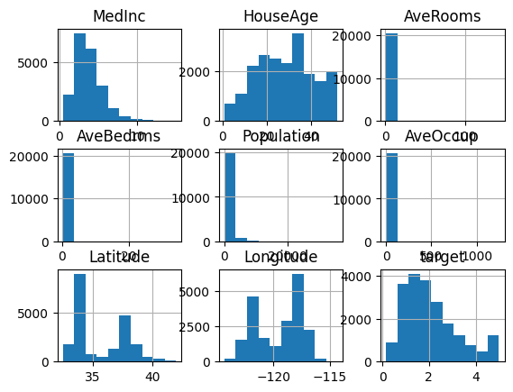

```python
df.hist()
```

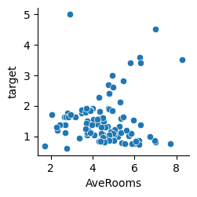

```python
import seaborn as sns
sns.pairplot(df.head(100), y_vars="target", x_vars='AveRooms')
# sns.pairplot(df, y_vars="target", x_vars=df.columns.values)
```

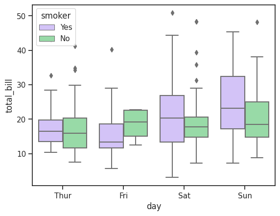

```python
sns.set_theme(style="ticks", palette="pastel")

# Load the example tips dataset
tips = sns.load_dataset("tips")

# Draw a nested boxplot to show bills by day and time
sns.boxplot(x="day", y="total_bill",
            hue="smoker", palette=["m", "g"],
            data=tips)
# sns.despine(offset=10, trim=True)
```

# Feature Engineering

- https://scikit-learn.org/stable/modules/classes.html#module-sklearn.preprocessing
- most modules have following methods
  - fit(y) - fit the model
  - fit_transform(y) - fit the model to data and transform it
  - inverse_transform(yt)
  - transform(y) - transform the given data using fitted model
  - and more depending on module

## Binarization

```python
# discover following commands
df = pd.DataFrame(iris['data'])
df.columns = iris['feature_names']
df['target'] = iris['target']

# df= pd.DataFrame(data= np.c_[iris['data'], iris['target']],columns= iris['feature_names'] + ['target'])
df['target_names'] = iris['target_names'][df['target']]
df
```

|  | sepal length (cm) | sepal width (cm) | petal length (cm) | petal width (cm) | target | target_names |
| --- | --- | --- | --- | --- | --- | --- |
| 0 | 5.1 | 3.5 | 1.4 | 0.2 | 0 | setosa |
| 1 | 4.9 | 3.0 | 1.4 | 0.2 | 0 | setosa |
| 2 | 4.7 | 3.2 | 1.3 | 0.2 | 0 | setosa |
| 3 | 4.6 | 3.1 | 1.5 | 0.2 | 0 | setosa |
| 4 | 5.0 | 3.6 | 1.4 | 0.2 | 0 | setosa |
| 5 | 5.4 | 3.9 | 1.7 | 0.4 | 0 | setosa |
| 6 | 4.6 | 3.4 | 1.4 | 0.3 | 0 | setosa |
| 7 | 5.0 | 3.4 | 1.5 | 0.2 | 0 | setosa |
| 8 | 4.4 | 2.9 | 1.4 | 0.2 | 0 | setosa |
| 9 | 4.9 | 3.1 | 1.5 | 0.1 | 0 | setosa |
| 10 | 5.4 | 3.7 | 1.5 | 0.2 | 0 | setosa |
| 11 | 4.8 | 3.4 | 1.6 | 0.2 | 0 | setosa |
| 12 | 4.8 | 3.0 | 1.4 | 0.1 | 0 | setosa |
| 13 | 4.3 | 3.0 | 1.1 | 0.1 | 0 | setosa |
| 14 | 5.8 | 4.0 | 1.2 | 0.2 | 0 | setosa |
| 15 | 5.7 | 4.4 | 1.5 | 0.4 | 0 | setosa |
| 16 | 5.4 | 3.9 | 1.3 | 0.4 | 0 | setosa |
| 17 | 5.1 | 3.5 | 1.4 | 0.3 | 0 | setosa |
| 18 | 5.7 | 3.8 | 1.7 | 0.3 | 0 | setosa |
| 19 | 5.1 | 3.8 | 1.5 | 0.3 | 0 | setosa |

150 rows × 6 columns

```python
iris['target_names']
```

```
array(['setosa', 'versicolor', 'virginica'], dtype='<U10')
```

```python
from sklearn.preprocessing import Binarizer
# SW bigger than 3 = 1
bn = Binarizer(threshold=3.0)
# bn.transform([df['sepal width (cm)']]) # returns 2 rank array
df['sw_bin']  = bn.transform([df['sepal width (cm)']])[0] # [0] is there because we want to get only axis 0 and convert this way the array to 1 rank array
df.head(20)
```

|  | sepal length (cm) | sepal width (cm) | petal length (cm) | petal width (cm) | target | target_names | sw_bin |
| --- | --- | --- | --- | --- | --- | --- | --- |
| 0 | 5.1 | 3.5 | 1.4 | 0.2 | 0 | setosa | 1.0 |
| 1 | 4.9 | 3.0 | 1.4 | 0.2 | 0 | setosa | 0.0 |
| 2 | 4.7 | 3.2 | 1.3 | 0.2 | 0 | setosa | 1.0 |
| 3 | 4.6 | 3.1 | 1.5 | 0.2 | 0 | setosa | 1.0 |
| 4 | 5.0 | 3.6 | 1.4 | 0.2 | 0 | setosa | 1.0 |
| 5 | 5.4 | 3.9 | 1.7 | 0.4 | 0 | setosa | 1.0 |
| 6 | 4.6 | 3.4 | 1.4 | 0.3 | 0 | setosa | 1.0 |
| 7 | 5.0 | 3.4 | 1.5 | 0.2 | 0 | setosa | 1.0 |
| 8 | 4.4 | 2.9 | 1.4 | 0.2 | 0 | setosa | 0.0 |
| 9 | 4.9 | 3.1 | 1.5 | 0.1 | 0 | setosa | 1.0 |
| 10 | 5.4 | 3.7 | 1.5 | 0.2 | 0 | setosa | 1.0 |
| 11 | 4.8 | 3.4 | 1.6 | 0.2 | 0 | setosa | 1.0 |
| 12 | 4.8 | 3.0 | 1.4 | 0.1 | 0 | setosa | 0.0 |
| 13 | 4.3 | 3.0 | 1.1 | 0.1 | 0 | setosa | 0.0 |
| 14 | 5.8 | 4.0 | 1.2 | 0.2 | 0 | setosa | 1.0 |
| 15 | 5.7 | 4.4 | 1.5 | 0.4 | 0 | setosa | 1.0 |
| 16 | 5.4 | 3.9 | 1.3 | 0.4 | 0 | setosa | 1.0 |
| 17 | 5.1 | 3.5 | 1.4 | 0.3 | 0 | setosa | 1.0 |
| 18 | 5.7 | 3.8 | 1.7 | 0.3 | 0 | setosa | 1.0 |
| 19 | 5.1 | 3.8 | 1.5 | 0.3 | 0 | setosa | 1.0 |

```python
bn.transform([df['sepal width (cm)']])[0]
```

```
array([1., 0., 1., 1., 1., 1., 1., 1., 0., 1., 1., 1., 0., 0., 1., 1., 1.,
       1., 1., 1., 1., 1., 1., 1., 1., 0., 1., 1., 1., 1., 1., 1., 1., 1.,
       1., 1., 1., 1., 0., 1., 1., 0., 1., 1., 1., 0., 1., 1., 1., 1., 1.,
       1., 1., 0., 0., 0., 1., 0., 0., 0., 0., 0., 0., 0., 0., 1., 0., 0.,
       0., 0., 1., 0., 0., 0., 0., 0., 0., 0., 0., 0., 0., 0., 0., 0., 0.,
       1., 1., 0., 0., 0., 0., 0., 0., 0., 0., 0., 0., 0., 0., 0., 1., 0.,
       0., 0., 0., 0., 0., 0., 0., 1., 1., 0., 0., 0., 0., 1., 0., 1., 0.,
       0., 1., 0., 0., 0., 1., 1., 0., 0., 0., 0., 0., 1., 0., 0., 0., 0.,
       1., 1., 0., 1., 1., 1., 0., 1., 1., 0., 0., 0., 1., 0.])
```

### Rounding

```python
# pd.round()
```

### Interactions

```python
from sklearn.preprocessing import PolynomialFeatures
pf = PolynomialFeatures(degree=2, interaction_only=False, include_bias=False)
df = df[['sepal length (cm)', 'sepal width (cm)']]

# fm = pf.fit(df)
# res = fm.transform(df)

res = pf.fit_transform(df)
# print(pf.powers_)
pd.DataFrame(res, columns=['sl', 'sw', 'sl^2', 'sl x sw', 'sw^2'])
```

|  | sl | sw | sl^2 | sl x sw | sw^2 |
| --- | --- | --- | --- | --- | --- |
| 0 | 5.1 | 3.5 | 26.01 | 17.85 | 12.25 |
| 1 | 4.9 | 3.0 | 24.01 | 14.70 | 9.00 |
| 2 | 4.7 | 3.2 | 22.09 | 15.04 | 10.24 |
| 3 | 4.6 | 3.1 | 21.16 | 14.26 | 9.61 |
| 4 | 5.0 | 3.6 | 25.00 | 18.00 | 12.96 |
| 5 | 5.4 | 3.9 | 29.16 | 21.06 | 15.21 |
| 6 | 4.6 | 3.4 | 21.16 | 15.64 | 11.56 |
| 7 | 5.0 | 3.4 | 25.00 | 17.00 | 11.56 |
| 8 | 4.4 | 2.9 | 19.36 | 12.76 | 8.41 |
| 9 | 4.9 | 3.1 | 24.01 | 15.19 | 9.61 |
| 10 | 5.4 | 3.7 | 29.16 | 19.98 | 13.69 |
| 11 | 4.8 | 3.4 | 23.04 | 16.32 | 11.56 |
| 12 | 4.8 | 3.0 | 23.04 | 14.40 | 9.00 |
| 13 | 4.3 | 3.0 | 18.49 | 12.90 | 9.00 |
| 14 | 5.8 | 4.0 | 33.64 | 23.20 | 16.00 |
| 15 | 5.7 | 4.4 | 32.49 | 25.08 | 19.36 |
| 16 | 5.4 | 3.9 | 29.16 | 21.06 | 15.21 |
| 17 | 5.1 | 3.5 | 26.01 | 17.85 | 12.25 |
| 18 | 5.7 | 3.8 | 32.49 | 21.66 | 14.44 |
| 19 | 5.1 | 3.8 | 26.01 | 19.38 | 14.44 |

150 rows × 5 columns

```python
# difference between fit_transform and transform
# The fit_transform(...) API function from scikit-learn is useful to build a feature engineering representation object on the training
# data, which can be reused on new data during model predictions by calling on the transform(...) function
# features used for predictions cannot be part of the training
new_df = pd.DataFrame([[6, 5],[3, 7], [7, 6]], columns=['sepal length (cm)', 'sepal width (cm)'])
new_res = pf.transform(new_df)
new_intr_features = pd.DataFrame(new_res, columns=['sl', 'sw', 'sl^2', 'sl x sw', 'sw^2'])
new_intr_features
```

|  | sl | sw | sl^2 | sl x sw | sw^2 |
| --- | --- | --- | --- | --- | --- |
| 0 | 6.0 | 5.0 | 36.0 | 30.0 | 25.0 |
| 1 | 3.0 | 7.0 | 9.0 | 21.0 | 49.0 |
| 2 | 7.0 | 6.0 | 49.0 | 42.0 | 36.0 |

### Fixed-Width Binning

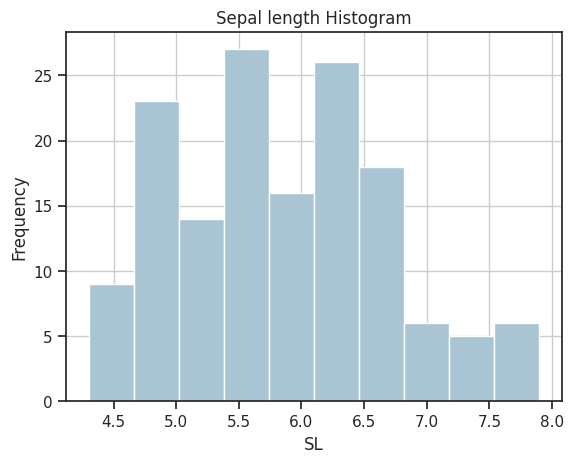

```python
import matplotlib.pyplot as plt
fig, ax = plt.subplots()
df['sepal length (cm)'].hist(color='#A9C5D3')
ax.set_title('Sepal length Histogram', fontsize=12)
ax.set_xlabel('SL', fontsize=12)
ax.set_ylabel('Frequency', fontsize=12)
```

```python
# approach 1 : floor of results of division
# approach 2 : pd.cut
bin_ranges = [0, 4, 5, 6, 7, 8]
bin_names = ['A', 'B', 'C', 'D', 'E'] # Bin labels must be one fewer than the number of bin edges

ranges = pd.cut(np.array(df['sepal length (cm)']), bins=bin_ranges)
df['SL_bin_custom_range'] = pd.cut(np.array(df['sepal length (cm)']), bins=bin_ranges)
# df['SL_bin_custom_label'] = pd.cut(np.array(df['sepal length (cm)']), bins=bin_ranges, labels=bin_names)

df
```

|  | sepal length (cm) | sepal width (cm) | SL_bin_custom_range |
| --- | --- | --- | --- |
| 0 | 5.1 | 3.5 | (5, 6] |
| 1 | 4.9 | 3.0 | (4, 5] |
| 2 | 4.7 | 3.2 | (4, 5] |
| 3 | 4.6 | 3.1 | (4, 5] |
| 4 | 5.0 | 3.6 | (4, 5] |
| 5 | 5.4 | 3.9 | (5, 6] |
| 6 | 4.6 | 3.4 | (4, 5] |
| 7 | 5.0 | 3.4 | (4, 5] |
| 8 | 4.4 | 2.9 | (4, 5] |
| 9 | 4.9 | 3.1 | (4, 5] |
| 10 | 5.4 | 3.7 | (5, 6] |
| 11 | 4.8 | 3.4 | (4, 5] |
| 12 | 4.8 | 3.0 | (4, 5] |
| 13 | 4.3 | 3.0 | (4, 5] |
| 14 | 5.8 | 4.0 | (5, 6] |
| 15 | 5.7 | 4.4 | (5, 6] |
| 16 | 5.4 | 3.9 | (5, 6] |
| 17 | 5.1 | 3.5 | (5, 6] |
| 18 | 5.7 | 3.8 | (5, 6] |
| 19 | 5.1 | 3.8 | (5, 6] |

150 rows × 3 columns

```python
ranges
```

```
[(5, 6], (4, 5], (4, 5], (4, 5], (4, 5], ..., (6, 7], (6, 7], (6, 7], (6, 7], (5, 6]]
Length: 150
Categories (5, interval[int64, right]): [(0, 4] < (4, 5] < (5, 6] < (6, 7] < (7, 8]]
```

### Adaptive Binning

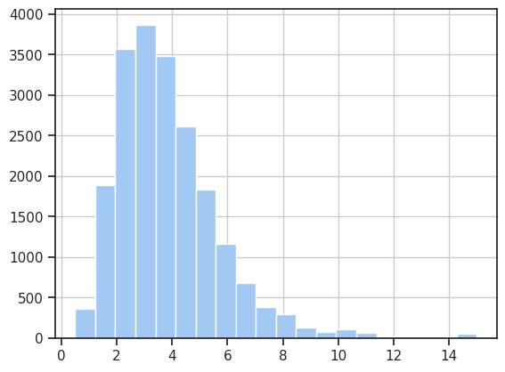

```python
df= pd.DataFrame(data= np.c_[housing['data'], housing['target']],columns= list(housing['feature_names']) + ['target'])
df['MedInc'].hist(bins=20)
```

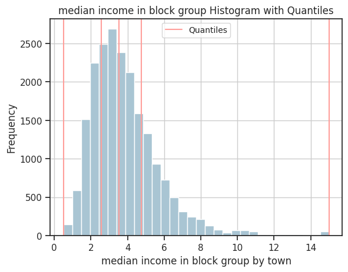

```python
import matplotlib.pyplot as plt
quantile_list = [0, .25, .5, .75, 1.]
quantiles = df['MedInc'].quantile(quantile_list)

# show quantile values for median income in block group
fig, ax = plt.subplots()
df['MedInc'].hist(bins=30, color='#A9C5D3')
for quantile in quantiles:
  qvl = plt.axvline(quantile, color='r')
ax.legend([qvl], ['Quantiles'], fontsize=10)
ax.set_title('median income in block group Histogram with Quantiles', fontsize=12)
ax.set_xlabel('median income in block group by town', fontsize=12)
ax.set_ylabel('Frequency', fontsize=12)
```

```python
quantile_labels = ['0-25Q', '25-50Q', '50-75Q', '75-100Q']
df['quantile_range'] = pd.qcut(df['MedInc'], q=quantile_list)
df['quantile_label'] = pd.qcut(df['MedInc'], q=quantile_list, labels=quantile_labels)
df[['MedInc', 'quantile_range', 'quantile_label']].iloc[4:9]
df.head(10)
```

|  | MedInc | HouseAge | AveRooms | AveBedrms | Population | AveOccup | Latitude | Longitude | target | quantile_range | quantile_label |
| --- | --- | --- | --- | --- | --- | --- | --- | --- | --- | --- | --- |
| 0 | 8.3252 | 41.0 | 6.984127 | 1.023810 | 322.0 | 2.555556 | 37.88 | -122.23 | 4.526 | (4.743, 15.0] | 75-100Q |
| 1 | 8.3014 | 21.0 | 6.238137 | 0.971880 | 2401.0 | 2.109842 | 37.86 | -122.22 | 3.585 | (4.743, 15.0] | 75-100Q |
| 2 | 7.2574 | 52.0 | 8.288136 | 1.073446 | 496.0 | 2.802260 | 37.85 | -122.24 | 3.521 | (4.743, 15.0] | 75-100Q |
| 3 | 5.6431 | 52.0 | 5.817352 | 1.073059 | 558.0 | 2.547945 | 37.85 | -122.25 | 3.413 | (4.743, 15.0] | 75-100Q |
| 4 | 3.8462 | 52.0 | 6.281853 | 1.081081 | 565.0 | 2.181467 | 37.85 | -122.25 | 3.422 | (3.535, 4.743] | 50-75Q |
| 5 | 4.0368 | 52.0 | 4.761658 | 1.103627 | 413.0 | 2.139896 | 37.85 | -122.25 | 2.697 | (3.535, 4.743] | 50-75Q |
| 6 | 3.6591 | 52.0 | 4.931907 | 0.951362 | 1094.0 | 2.128405 | 37.84 | -122.25 | 2.992 | (3.535, 4.743] | 50-75Q |
| 7 | 3.1200 | 52.0 | 4.797527 | 1.061824 | 1157.0 | 1.788253 | 37.84 | -122.25 | 2.414 | (2.563, 3.535] | 25-50Q |
| 8 | 2.0804 | 42.0 | 4.294118 | 1.117647 | 1206.0 | 2.026891 | 37.84 | -122.26 | 2.267 | (0.499, 2.563] | 0-25Q |
| 9 | 3.6912 | 52.0 | 4.970588 | 0.990196 | 1551.0 | 2.172269 | 37.84 | -122.25 | 2.611 | (3.535, 4.743] | 50-75Q |

### Stats Transform - Homework

#### Box-Cox

```python
# np.log
# estimate optimal lambda - spstats.boxcox()
```

## Feature Engineering - Categorical data

### Transforming Nominal Features

```python
# read data
df= pd.DataFrame(data= np.c_[iris['data'], iris['target']],columns= list(iris['feature_names']) + ['target'])
df['target_names'] = iris.target_names[df['target'].astype(int)]
df
```

|  | sepal length (cm) | sepal width (cm) | petal length (cm) | petal width (cm) | target | target_names |
| --- | --- | --- | --- | --- | --- | --- |
| 0 | 5.1 | 3.5 | 1.4 | 0.2 | 0.0 | setosa |
| 1 | 4.9 | 3.0 | 1.4 | 0.2 | 0.0 | setosa |
| 2 | 4.7 | 3.2 | 1.3 | 0.2 | 0.0 | setosa |
| 3 | 4.6 | 3.1 | 1.5 | 0.2 | 0.0 | setosa |
| 4 | 5.0 | 3.6 | 1.4 | 0.2 | 0.0 | setosa |
| 5 | 5.4 | 3.9 | 1.7 | 0.4 | 0.0 | setosa |
| 6 | 4.6 | 3.4 | 1.4 | 0.3 | 0.0 | setosa |
| 7 | 5.0 | 3.4 | 1.5 | 0.2 | 0.0 | setosa |
| 8 | 4.4 | 2.9 | 1.4 | 0.2 | 0.0 | setosa |
| 9 | 4.9 | 3.1 | 1.5 | 0.1 | 0.0 | setosa |
| 10 | 5.4 | 3.7 | 1.5 | 0.2 | 0.0 | setosa |
| 11 | 4.8 | 3.4 | 1.6 | 0.2 | 0.0 | setosa |
| 12 | 4.8 | 3.0 | 1.4 | 0.1 | 0.0 | setosa |
| 13 | 4.3 | 3.0 | 1.1 | 0.1 | 0.0 | setosa |
| 14 | 5.8 | 4.0 | 1.2 | 0.2 | 0.0 | setosa |
| 15 | 5.7 | 4.4 | 1.5 | 0.4 | 0.0 | setosa |
| 16 | 5.4 | 3.9 | 1.3 | 0.4 | 0.0 | setosa |
| 17 | 5.1 | 3.5 | 1.4 | 0.3 | 0.0 | setosa |
| 18 | 5.7 | 3.8 | 1.7 | 0.3 | 0.0 | setosa |
| 19 | 5.1 | 3.8 | 1.5 | 0.3 | 0.0 | setosa |

150 rows × 6 columns

```python
# get all target names to be encoded to numerical labels
# this is just for exercise as we already have numericallabels in column target
flowers = np.unique(df['target_names'])
flowers
```

```
array(['setosa', 'versicolor', 'virginica'], dtype=object)
```

```python
# maping names to label using LabelEncoder() method
from sklearn.preprocessing import LabelEncoder
le = LabelEncoder()
labels = le.fit_transform(df['target_names']) # take target names and encode it to labels
print(labels)

# create new column with label
df['flowerlabel'] = labels
df
```

```
[0 0 0 0 0 0 0 0 0 0 0 0 0 0 0 0 0 0 0 0 0 0 0 0 0 0 0 0 0 0 0 0 0 0 0 0 0
 0 0 0 0 0 0 0 0 0 0 0 0 0 1 1 1 1 1 1 1 1 1 1 1 1 1 1 1 1 1 1 1 1 1 1 1 1
 1 1 1 1 1 1 1 1 1 1 1 1 1 1 1 1 1 1 1 1 1 1 1 1 1 1 2 2 2 2 2 2 2 2 2 2 2
 2 2 2 2 2 2 2 2 2 2 2 2 2 2 2 2 2 2 2 2 2 2 2 2 2 2 2 2 2 2 2 2 2 2 2 2 2
 2 2]
```

|  | sepal length (cm) | sepal width (cm) | petal length (cm) | petal width (cm) | target | target_names | flowerlabel |
| --- | --- | --- | --- | --- | --- | --- | --- |
| 0 | 5.1 | 3.5 | 1.4 | 0.2 | 0.0 | setosa | 0 |
| 1 | 4.9 | 3.0 | 1.4 | 0.2 | 0.0 | setosa | 0 |
| 2 | 4.7 | 3.2 | 1.3 | 0.2 | 0.0 | setosa | 0 |
| 3 | 4.6 | 3.1 | 1.5 | 0.2 | 0.0 | setosa | 0 |
| 4 | 5.0 | 3.6 | 1.4 | 0.2 | 0.0 | setosa | 0 |
| 5 | 5.4 | 3.9 | 1.7 | 0.4 | 0.0 | setosa | 0 |
| 6 | 4.6 | 3.4 | 1.4 | 0.3 | 0.0 | setosa | 0 |
| 7 | 5.0 | 3.4 | 1.5 | 0.2 | 0.0 | setosa | 0 |
| 8 | 4.4 | 2.9 | 1.4 | 0.2 | 0.0 | setosa | 0 |
| 9 | 4.9 | 3.1 | 1.5 | 0.1 | 0.0 | setosa | 0 |
| 10 | 5.4 | 3.7 | 1.5 | 0.2 | 0.0 | setosa | 0 |
| 11 | 4.8 | 3.4 | 1.6 | 0.2 | 0.0 | setosa | 0 |
| 12 | 4.8 | 3.0 | 1.4 | 0.1 | 0.0 | setosa | 0 |
| 13 | 4.3 | 3.0 | 1.1 | 0.1 | 0.0 | setosa | 0 |
| 14 | 5.8 | 4.0 | 1.2 | 0.2 | 0.0 | setosa | 0 |
| 15 | 5.7 | 4.4 | 1.5 | 0.4 | 0.0 | setosa | 0 |
| 16 | 5.4 | 3.9 | 1.3 | 0.4 | 0.0 | setosa | 0 |
| 17 | 5.1 | 3.5 | 1.4 | 0.3 | 0.0 | setosa | 0 |
| 18 | 5.7 | 3.8 | 1.7 | 0.3 | 0.0 | setosa | 0 |
| 19 | 5.1 | 3.8 | 1.5 | 0.3 | 0.0 | setosa | 0 |

150 rows × 7 columns

```python
# to create dictionary containing the mapping from label to target name
print(le.classes_) # prints classes learned from data when fitting LabelEncoder()

# explain enumerate
# ?enumerate
enum = enumerate(le.classes_)
for count, value in enum:
  print(count, value)

# create dictionary using enumerate
mappings = {index: label for index, label in enumerate(le.classes_)}
print(mappings)
```

```
['setosa' 'versicolor' 'virginica']
0 setosa
1 versicolor
2 virginica
{0: 'setosa', 1: 'versicolor', 2: 'virginica'}
```

#### Using category codes approach

- an introduction to pandas categorical data type, including a short comparison with R’s factor.
- https://pandas.pydata.org/pandas-docs/stable/user_guide/categorical.html#

```python
# converting type of columns to 'category'
df['cat'] = df['target_names'].astype('category')
print(df.dtypes)
# Assigning numerical values and storing in another column
df['target_names_label'] = df['cat'].cat.codes
df
```

```
sepal length (cm)     float64
sepal width (cm)      float64
petal length (cm)     float64
petal width (cm)      float64
target                float64
target_names           object
flowerlabel             int64
cat                  category
dtype: object
```

|  | sepal length (cm) | sepal width (cm) | petal length (cm) | petal width (cm) | target | target_names | flowerlabel | cat | target_names_label |
| --- | --- | --- | --- | --- | --- | --- | --- | --- | --- |
| 0 | 5.1 | 3.5 | 1.4 | 0.2 | 0.0 | setosa | 0 | setosa | 0 |
| 1 | 4.9 | 3.0 | 1.4 | 0.2 | 0.0 | setosa | 0 | setosa | 0 |
| 2 | 4.7 | 3.2 | 1.3 | 0.2 | 0.0 | setosa | 0 | setosa | 0 |
| 3 | 4.6 | 3.1 | 1.5 | 0.2 | 0.0 | setosa | 0 | setosa | 0 |
| 4 | 5.0 | 3.6 | 1.4 | 0.2 | 0.0 | setosa | 0 | setosa | 0 |
| 5 | 5.4 | 3.9 | 1.7 | 0.4 | 0.0 | setosa | 0 | setosa | 0 |
| 6 | 4.6 | 3.4 | 1.4 | 0.3 | 0.0 | setosa | 0 | setosa | 0 |
| 7 | 5.0 | 3.4 | 1.5 | 0.2 | 0.0 | setosa | 0 | setosa | 0 |
| 8 | 4.4 | 2.9 | 1.4 | 0.2 | 0.0 | setosa | 0 | setosa | 0 |
| 9 | 4.9 | 3.1 | 1.5 | 0.1 | 0.0 | setosa | 0 | setosa | 0 |
| 10 | 5.4 | 3.7 | 1.5 | 0.2 | 0.0 | setosa | 0 | setosa | 0 |
| 11 | 4.8 | 3.4 | 1.6 | 0.2 | 0.0 | setosa | 0 | setosa | 0 |
| 12 | 4.8 | 3.0 | 1.4 | 0.1 | 0.0 | setosa | 0 | setosa | 0 |
| 13 | 4.3 | 3.0 | 1.1 | 0.1 | 0.0 | setosa | 0 | setosa | 0 |
| 14 | 5.8 | 4.0 | 1.2 | 0.2 | 0.0 | setosa | 0 | setosa | 0 |
| 15 | 5.7 | 4.4 | 1.5 | 0.4 | 0.0 | setosa | 0 | setosa | 0 |
| 16 | 5.4 | 3.9 | 1.3 | 0.4 | 0.0 | setosa | 0 | setosa | 0 |
| 17 | 5.1 | 3.5 | 1.4 | 0.3 | 0.0 | setosa | 0 | setosa | 0 |
| 18 | 5.7 | 3.8 | 1.7 | 0.3 | 0.0 | setosa | 0 | setosa | 0 |
| 19 | 5.1 | 3.8 | 1.5 | 0.3 | 0.0 | setosa | 0 | setosa | 0 |

150 rows × 9 columns

#### Transforming Ordinal Features

- here order of categorical values matters

```python
# say that setosa is 1st, virginica 2nd, and versicolor 3rd and it play some role in the dataset
mappings = {'setosa': 1, 'virginica': 2, 'versicolor': 3} # switched keys and values when compared to the previous case
print(mappings)
# use map function to remap a 'target_names' to a specific label in order given by 'mappings' dictionary
df['FlowerGenerationLabel'] = df['target_names'].map(mappings)
df
```

```
{'setosa': 1, 'virginica': 2, 'versicolor': 3}
```

|  | sepal length (cm) | sepal width (cm) | petal length (cm) | petal width (cm) | target | target_names | flowerlabel | cat | target_names_label | FlowerGenerationLabel |
| --- | --- | --- | --- | --- | --- | --- | --- | --- | --- | --- |
| 0 | 5.1 | 3.5 | 1.4 | 0.2 | 0.0 | setosa | 0 | setosa | 0 | 1 |
| 1 | 4.9 | 3.0 | 1.4 | 0.2 | 0.0 | setosa | 0 | setosa | 0 | 1 |
| 2 | 4.7 | 3.2 | 1.3 | 0.2 | 0.0 | setosa | 0 | setosa | 0 | 1 |
| 3 | 4.6 | 3.1 | 1.5 | 0.2 | 0.0 | setosa | 0 | setosa | 0 | 1 |
| 4 | 5.0 | 3.6 | 1.4 | 0.2 | 0.0 | setosa | 0 | setosa | 0 | 1 |
| 5 | 5.4 | 3.9 | 1.7 | 0.4 | 0.0 | setosa | 0 | setosa | 0 | 1 |
| 6 | 4.6 | 3.4 | 1.4 | 0.3 | 0.0 | setosa | 0 | setosa | 0 | 1 |
| 7 | 5.0 | 3.4 | 1.5 | 0.2 | 0.0 | setosa | 0 | setosa | 0 | 1 |
| 8 | 4.4 | 2.9 | 1.4 | 0.2 | 0.0 | setosa | 0 | setosa | 0 | 1 |
| 9 | 4.9 | 3.1 | 1.5 | 0.1 | 0.0 | setosa | 0 | setosa | 0 | 1 |
| 10 | 5.4 | 3.7 | 1.5 | 0.2 | 0.0 | setosa | 0 | setosa | 0 | 1 |
| 11 | 4.8 | 3.4 | 1.6 | 0.2 | 0.0 | setosa | 0 | setosa | 0 | 1 |
| 12 | 4.8 | 3.0 | 1.4 | 0.1 | 0.0 | setosa | 0 | setosa | 0 | 1 |
| 13 | 4.3 | 3.0 | 1.1 | 0.1 | 0.0 | setosa | 0 | setosa | 0 | 1 |
| 14 | 5.8 | 4.0 | 1.2 | 0.2 | 0.0 | setosa | 0 | setosa | 0 | 1 |
| 15 | 5.7 | 4.4 | 1.5 | 0.4 | 0.0 | setosa | 0 | setosa | 0 | 1 |
| 16 | 5.4 | 3.9 | 1.3 | 0.4 | 0.0 | setosa | 0 | setosa | 0 | 1 |
| 17 | 5.1 | 3.5 | 1.4 | 0.3 | 0.0 | setosa | 0 | setosa | 0 | 1 |
| 18 | 5.7 | 3.8 | 1.7 | 0.3 | 0.0 | setosa | 0 | setosa | 0 | 1 |
| 19 | 5.1 | 3.8 | 1.5 | 0.3 | 0.0 | setosa | 0 | setosa | 0 | 1 |

150 rows × 10 columns

### Encoding features

#### One-Hot Encoding

- label encoding problem
  - numeric values can be misinterpreted by algorithms as having some sort of hierarchy/order in them
- one hot encoding solves this issue
- encodes feature to m binary features - to get numeric representation of categorical feature
  - in this strategy, each category value is converted into a new column and assigned a 1 or 0 (notation for true/false) value to the column.
  - so it encodes a feature to m binary features
  - m depends on a number of categories

#### Dummy encoding

- python one-line of code
- this approach is more flexible because it allows encoding as many category columns as you would like and choose how to label the columns using a prefix
- proper naming will make the rest of the analysis just a little bit easier.

#### !!! DUMMY VARIABLE TRAP !!!

- one-hot-encoding, dummy encoding with not specified syntax
  - multicolinearity issue - features are not independent, problem with interpretability of regression models, random behaviour of model
  - https://www.analyticsvidhya.com/blog/2020/03/what-is-multicollinearity/
- to avoid multicolinearity
  - using m-1 feature vector to represent each categorical feature, one categorical feature is represented by vector of 0

```python
my_list = [{'car': 'Toyota', 'price per day': 50, 'milage': 4852, 'color':'black'},
           {'car': 'VW', 'price per day': 70, 'milage': 123, 'color':'white'},
           {'car': 'BMW', 'price per day': 65, 'milage': 2548, 'color':'black'}]
df = pd.DataFrame(my_list)
print(df)
# two categorical features
```

```
      car  price per day  milage  color
0  Toyota             50    4852  black
1      VW             70     123  white
2     BMW             65    2548  black
```

```python
# first convert categorical variable car to a numeric representation/label
from sklearn.preprocessing import OneHotEncoder, LabelEncoder
le = LabelEncoder()
labels = le.fit_transform(df['car'])
df['carlabel'] = labels
df
```

|  | car | price per day | milage | color | carlabel |
| --- | --- | --- | --- | --- | --- |
| 0 | Toyota | 50 | 4852 | black | 1 |
| 1 | VW | 70 | 123 | white | 2 |
| 2 | BMW | 65 | 2548 | black | 0 |

```python
# encode carlabel using one-hot encoding scheme
ohe =  OneHotEncoder()

# ohe_feature = ohe.fit_transform(df[['carlabel']])
ohe_feature = ohe.fit_transform(df[['car']]) # new pandas version car work with object type
print(ohe_feature)
# convert output of ohe to array
ohe_feature_array = ohe.fit_transform(df[['car']]).toarray()
print(ohe_feature_array)

# assign feature names to columns
# ohe_feature_labels = ['car-'+str(cls_label) for cls_label in le.classes_]
ohe_feature_labels = ['car-'+str(cls_label) for cls_label in ohe.categories_[0]]
print(ohe_feature_labels)

ohe_features = pd.DataFrame(ohe_feature_array, columns=ohe_feature_labels)
ohe_features
```

```
  (0, 1)	1.0
  (1, 2)	1.0
  (2, 0)	1.0
[[0. 1. 0.]
 [0. 0. 1.]
 [1. 0. 0.]]
['car-BMW', 'car-Toyota', 'car-VW']
```

|  | car-BMW | car-Toyota | car-VW |
| --- | --- | --- | --- |
| 0 | 0.0 | 1.0 | 0.0 |
| 1 | 0.0 | 0.0 | 1.0 |
| 2 | 1.0 | 0.0 | 0.0 |

```python
#concat new binary features to the original dataframe
df = pd.concat([df, ohe_features], axis=1)
# df.drop(columns=['car'])
df
```

|  | car | price per day | milage | color | carlabel | car-BMW | car-Toyota | car-VW |
| --- | --- | --- | --- | --- | --- | --- | --- | --- |
| 0 | Toyota | 50 | 4852 | black | 1 | 0.0 | 1.0 | 0.0 |
| 1 | VW | 70 | 123 | white | 2 | 0.0 | 0.0 | 1.0 |
| 2 | BMW | 65 | 2548 | black | 0 | 1.0 | 0.0 | 0.0 |

```python
# easy one hot encoding :)
pd.get_dummies(df['car'])
```

|  | BMW | Toyota | VW |
| --- | --- | --- | --- |
| 0 | 0 | 1 | 0 |
| 1 | 0 | 0 | 1 |
| 2 | 1 | 0 | 0 |

```python
# avoid multicolinearity
# dummy encoding
pd.get_dummies(df['car'], drop_first=True)
```

|  | Toyota | VW |
| --- | --- | --- |
| 0 | 1 | 0 |
| 1 | 0 | 1 |
| 2 | 0 | 0 |

### Bin-Counting, feature hashing, embeding

- m categorical feature - m separate features - problem with high number of binary features representing all categorical features
- curse of dimensionality
- out of scope - more materials online if needed
- https://towardsdatascience.com/feature-engineering-examples-binning-categorical-features-9f8d582455da
- hashing - shorten the number of features to represent m categorical features

## Feature Engineering - Text Data

- Preprocessing
  - nltk.WordPunctTokenizer()
- Bag of words
  - from sklearn.feature_extraction.text import CountVectorizer
- Mostly for NLP - see NLP CAS course

## Feature Engineering - Time Series Data

```python
# possibly relevant packages
# import datetime
# from dateutil.parser import parse
# import pytz

# define data as timeseries
time_stamps = ['2015-03-08 10:30:00.360000+00:00', '2017-07-13 15:45:05.755000-07:00', '2012-01-20 22:30:00.254000+05:30', '2016-12-25 00:30:00.000000+10:00']
df = pd.DataFrame(time_stamps, columns=['Time'])
df
```

|  | Time |
| --- | --- |
| 0 | 2015-03-08 10:30:00.360000+00:00 |
| 1 | 2017-07-13 15:45:05.755000-07:00 |
| 2 | 2012-01-20 22:30:00.254000+05:30 |
| 3 | 2016-12-25 00:30:00.000000+10:00 |

```python
# convert to timestamp
ts_objs = np.array([pd.Timestamp(item) for item in np.array(df.Time)])
df['TS_obj'] = ts_objs
print(ts_objs)
df
```

```
[Timestamp('2015-03-08 10:30:00.360000+0000', tz='UTC')
 Timestamp('2017-07-13 15:45:05.755000-0700', tz='pytz.FixedOffset(-420)')
 Timestamp('2012-01-20 22:30:00.254000+0530', tz='pytz.FixedOffset(330)')
 Timestamp('2016-12-25 00:30:00+1000', tz='pytz.FixedOffset(600)')]
```

|  | Time | TS_obj |
| --- | --- | --- |
| 0 | 2015-03-08 10:30:00.360000+00:00 | 2015-03-08 10:30:00.360000+00:00 |
| 1 | 2017-07-13 15:45:05.755000-07:00 | 2017-07-13 15:45:05.755000-07:00 |
| 2 | 2012-01-20 22:30:00.254000+05:30 | 2012-01-20 22:30:00.254000+05:30 |
| 3 | 2016-12-25 00:30:00.000000+10:00 | 2016-12-25 00:30:00+10:00 |

```python
# useful timeseries mentods to get time relevant features

# lambda function syntax >> "lambda arguments : expression"
# A lambda function is a small anonymous function.
# A lambda function can take any number of arguments, but can only have one expression.

df['Year'] = df['TS_obj'].apply(lambda d: d.year)
df['Month'] = df['TS_obj'].apply(lambda d: d.month)
df['Day'] = df['TS_obj'].apply(lambda d: d.day)
df['DayOfWeek'] = df['TS_obj'].apply(lambda d: d.dayofweek)
df['DayName'] = df['TS_obj'].apply(lambda d: d.day_name())
df['DayOfYear'] = df['TS_obj'].apply(lambda d: d.dayofyear)
df['WeekOfYear'] = df['TS_obj'].apply(lambda d: d.weekofyear)
df['Quarter'] = df['TS_obj'].apply(lambda d: d.quarter)
df[['Time', 'Year', 'Month', 'Day', 'Quarter', 'DayOfWeek', 'DayName', 'DayOfYear', 'WeekOfYear']]
```

|  | Time | Year | Month | Day | Quarter | DayOfWeek | DayName | DayOfYear | WeekOfYear |
| --- | --- | --- | --- | --- | --- | --- | --- | --- | --- |
| 0 | 2015-03-08 10:30:00.360000+00:00 | 2015 | 3 | 8 | 1 | 6 | Sunday | 67 | 10 |
| 1 | 2017-07-13 15:45:05.755000-07:00 | 2017 | 7 | 13 | 3 | 3 | Thursday | 194 | 28 |
| 2 | 2012-01-20 22:30:00.254000+05:30 | 2012 | 1 | 20 | 1 | 4 | Friday | 20 | 3 |
| 3 | 2016-12-25 00:30:00.000000+10:00 | 2016 | 12 | 25 | 4 | 6 | Sunday | 360 | 51 |

```python
df['Hour'] = df['TS_obj'].apply(lambda d: d.hour)
df['Minute'] = df['TS_obj'].apply(lambda d: d.minute)
df['Second'] = df['TS_obj'].apply(lambda d: d.second)
df['MUsecond'] = df['TS_obj'].apply(lambda d: d.microsecond)
df['UTC_offset'] = df['TS_obj'].apply(lambda d: d.utcoffset())
df[['Time', 'Hour', 'Minute', 'Second', 'MUsecond', 'UTC_offset']]
```

|  | Time | Hour | Minute | Second | MUsecond | UTC_offset |
| --- | --- | --- | --- | --- | --- | --- |
| 0 | 2015-03-08 10:30:00.360000+00:00 | 10 | 30 | 0 | 360000 | 0 days 00:00:00 |
| 1 | 2017-07-13 15:45:05.755000-07:00 | 15 | 45 | 5 | 755000 | -1 days +17:00:00 |
| 2 | 2012-01-20 22:30:00.254000+05:30 | 22 | 30 | 0 | 254000 | 0 days 05:30:00 |
| 3 | 2016-12-25 00:30:00.000000+10:00 | 0 | 30 | 0 | 0 | 0 days 10:00:00 |

# Feature Scaling

```python
df= pd.DataFrame(data= np.c_[housing['data'], housing['target']],columns= list(housing['feature_names']) + ['target'])
df
```

|  | MedInc | HouseAge | AveRooms | AveBedrms | Population | AveOccup | Latitude | Longitude | target |
| --- | --- | --- | --- | --- | --- | --- | --- | --- | --- |
| 0 | 8.3252 | 41.0 | 6.984127 | 1.023810 | 322.0 | 2.555556 | 37.88 | -122.23 | 4.526 |
| 1 | 8.3014 | 21.0 | 6.238137 | 0.971880 | 2401.0 | 2.109842 | 37.86 | -122.22 | 3.585 |
| 2 | 7.2574 | 52.0 | 8.288136 | 1.073446 | 496.0 | 2.802260 | 37.85 | -122.24 | 3.521 |
| 3 | 5.6431 | 52.0 | 5.817352 | 1.073059 | 558.0 | 2.547945 | 37.85 | -122.25 | 3.413 |
| 4 | 3.8462 | 52.0 | 6.281853 | 1.081081 | 565.0 | 2.181467 | 37.85 | -122.25 | 3.422 |
| 5 | 4.0368 | 52.0 | 4.761658 | 1.103627 | 413.0 | 2.139896 | 37.85 | -122.25 | 2.697 |
| 6 | 3.6591 | 52.0 | 4.931907 | 0.951362 | 1094.0 | 2.128405 | 37.84 | -122.25 | 2.992 |
| 7 | 3.1200 | 52.0 | 4.797527 | 1.061824 | 1157.0 | 1.788253 | 37.84 | -122.25 | 2.414 |
| 8 | 2.0804 | 42.0 | 4.294118 | 1.117647 | 1206.0 | 2.026891 | 37.84 | -122.26 | 2.267 |
| 9 | 3.6912 | 52.0 | 4.970588 | 0.990196 | 1551.0 | 2.172269 | 37.84 | -122.25 | 2.611 |
| 10 | 3.2031 | 52.0 | 5.477612 | 1.079602 | 910.0 | 2.263682 | 37.85 | -122.26 | 2.815 |
| 11 | 3.2705 | 52.0 | 4.772480 | 1.024523 | 1504.0 | 2.049046 | 37.85 | -122.26 | 2.418 |
| 12 | 3.0750 | 52.0 | 5.322650 | 1.012821 | 1098.0 | 2.346154 | 37.85 | -122.26 | 2.135 |
| 13 | 2.6736 | 52.0 | 4.000000 | 1.097701 | 345.0 | 1.982759 | 37.84 | -122.26 | 1.913 |
| 14 | 1.9167 | 52.0 | 4.262903 | 1.009677 | 1212.0 | 1.954839 | 37.85 | -122.26 | 1.592 |
| 15 | 2.1250 | 50.0 | 4.242424 | 1.071970 | 697.0 | 2.640152 | 37.85 | -122.26 | 1.400 |
| 16 | 2.7750 | 52.0 | 5.939577 | 1.048338 | 793.0 | 2.395770 | 37.85 | -122.27 | 1.525 |
| 17 | 2.1202 | 52.0 | 4.052805 | 0.966997 | 648.0 | 2.138614 | 37.85 | -122.27 | 1.555 |
| 18 | 1.9911 | 50.0 | 5.343675 | 1.085919 | 990.0 | 2.362768 | 37.84 | -122.26 | 1.587 |
| 19 | 2.6033 | 52.0 | 5.465455 | 1.083636 | 690.0 | 2.509091 | 37.84 | -122.27 | 1.629 |

20640 rows × 9 columns

```python
# apply different feature scaling methods using scikit only on one column and see differences
from sklearn.preprocessing import StandardScaler, MinMaxScaler, RobustScaler
ss = StandardScaler()
mms = MinMaxScaler()
rs = RobustScaler()
Population = pd.DataFrame(df['Population'])
Population['SS - Population'] = ss.fit_transform(df[['Population']])
Population['MM - Population'] = mms.fit_transform(df[['Population']])
Population['RS - Population'] = rs.fit_transform(df[['Population']])
Population
```

|  | Population | SS - Population | MM - Population | RS - Population |
| --- | --- | --- | --- | --- |
| 0 | 322.0 | -0.974429 | 0.008941 | -0.899787 |
| 1 | 2401.0 | 0.861439 | 0.067210 | 1.316631 |
| 2 | 496.0 | -0.820777 | 0.013818 | -0.714286 |
| 3 | 558.0 | -0.766028 | 0.015555 | -0.648188 |
| 4 | 565.0 | -0.759847 | 0.015752 | -0.640725 |
| 5 | 413.0 | -0.894071 | 0.011491 | -0.802772 |
| 6 | 1094.0 | -0.292712 | 0.030578 | -0.076759 |
| 7 | 1157.0 | -0.237079 | 0.032344 | -0.009595 |
| 8 | 1206.0 | -0.193810 | 0.033717 | 0.042644 |
| 9 | 1551.0 | 0.110844 | 0.043387 | 0.410448 |
| 10 | 910.0 | -0.455193 | 0.025421 | -0.272921 |
| 11 | 1504.0 | 0.069340 | 0.042070 | 0.360341 |
| 12 | 1098.0 | -0.289179 | 0.030690 | -0.072495 |
| 13 | 345.0 | -0.954118 | 0.009585 | -0.875267 |
| 14 | 1212.0 | -0.188511 | 0.033885 | 0.049041 |
| 15 | 697.0 | -0.643284 | 0.019451 | -0.500000 |
| 16 | 793.0 | -0.558511 | 0.022142 | -0.397655 |
| 17 | 648.0 | -0.686553 | 0.018078 | -0.552239 |
| 18 | 990.0 | -0.384549 | 0.027663 | -0.187633 |
| 19 | 690.0 | -0.649465 | 0.019255 | -0.507463 |

20640 rows × 4 columns

```python
# min max scaler applied on entire df
df2 = pd.DataFrame(mms.fit_transform(df), columns = df.columns)
df2
```

|  | MedInc | HouseAge | AveRooms | AveBedrms | Population | AveOccup | Latitude | Longitude | target |
| --- | --- | --- | --- | --- | --- | --- | --- | --- | --- |
| 0 | 0.539668 | 0.784314 | 0.043512 | 0.020469 | 0.008941 | 0.001499 | 0.567481 | 0.211155 | 0.902266 |
| 1 | 0.538027 | 0.392157 | 0.038224 | 0.018929 | 0.067210 | 0.001141 | 0.565356 | 0.212151 | 0.708247 |
| 2 | 0.466028 | 1.000000 | 0.052756 | 0.021940 | 0.013818 | 0.001698 | 0.564293 | 0.210159 | 0.695051 |
| 3 | 0.354699 | 1.000000 | 0.035241 | 0.021929 | 0.015555 | 0.001493 | 0.564293 | 0.209163 | 0.672783 |
| 4 | 0.230776 | 1.000000 | 0.038534 | 0.022166 | 0.015752 | 0.001198 | 0.564293 | 0.209163 | 0.674638 |
| 5 | 0.243921 | 1.000000 | 0.027757 | 0.022835 | 0.011491 | 0.001165 | 0.564293 | 0.209163 | 0.525155 |
| 6 | 0.217873 | 1.000000 | 0.028964 | 0.018321 | 0.030578 | 0.001156 | 0.563231 | 0.209163 | 0.585979 |
| 7 | 0.180694 | 1.000000 | 0.028011 | 0.021596 | 0.032344 | 0.000882 | 0.563231 | 0.209163 | 0.466804 |
| 8 | 0.108998 | 0.803922 | 0.024443 | 0.023250 | 0.033717 | 0.001074 | 0.563231 | 0.208167 | 0.436495 |
| 9 | 0.220087 | 1.000000 | 0.029238 | 0.019472 | 0.043387 | 0.001191 | 0.563231 | 0.209163 | 0.507423 |
| 10 | 0.186425 | 1.000000 | 0.032833 | 0.022123 | 0.025421 | 0.001265 | 0.564293 | 0.208167 | 0.549484 |
| 11 | 0.191073 | 1.000000 | 0.027834 | 0.020490 | 0.042070 | 0.001092 | 0.564293 | 0.208167 | 0.467629 |
| 12 | 0.177591 | 1.000000 | 0.031734 | 0.020143 | 0.030690 | 0.001331 | 0.564293 | 0.208167 | 0.409279 |
| 13 | 0.149908 | 1.000000 | 0.022358 | 0.022659 | 0.009585 | 0.001038 | 0.563231 | 0.208167 | 0.363506 |
| 14 | 0.097709 | 1.000000 | 0.024221 | 0.020050 | 0.033885 | 0.001016 | 0.564293 | 0.208167 | 0.297320 |
| 15 | 0.112074 | 0.960784 | 0.024076 | 0.021896 | 0.019451 | 0.001568 | 0.564293 | 0.208167 | 0.257733 |
| 16 | 0.156901 | 1.000000 | 0.036107 | 0.021196 | 0.022142 | 0.001371 | 0.564293 | 0.207171 | 0.283506 |
| 17 | 0.111743 | 1.000000 | 0.022732 | 0.018784 | 0.018078 | 0.001164 | 0.564293 | 0.207171 | 0.289692 |
| 18 | 0.102840 | 0.960784 | 0.031883 | 0.022310 | 0.027663 | 0.001344 | 0.563231 | 0.208167 | 0.296289 |
| 19 | 0.145060 | 1.000000 | 0.032746 | 0.022242 | 0.019255 | 0.001462 | 0.563231 | 0.207171 | 0.304949 |

20640 rows × 9 columns

## Feature selection

```python
# VarianceThreshold is a simple baseline approach to feature selection.
# It removes all features whose variance doesn’t meet some threshold.
# By default, it removes all zero-variance features, i.e. features that have the same value in all samples.
from sklearn.feature_selection import VarianceThreshold
vt = VarianceThreshold(threshold=0.001)
vt.fit(df2) # we need to have same scalling on features with preserved variance - setign up the threshold can be tricky
pd.DataFrame({'variance': vt.variances_, 'select_feature': vt.get_support()}, index=df.columns).T
```

|  | MedInc | HouseAge | AveRooms | AveBedrms | Population | AveOccup | Latitude | Longitude | target |
| --- | --- | --- | --- | --- | --- | --- | --- | --- | --- |
| variance | 0.017166 | 0.060895 | 0.000308 | 0.000197 | 0.001007 | 0.00007 | 0.051521 | 0.03982 | 0.056607 |
| select_feature | True | True | False | False | True | False | True | True | True |

```
array([[<Axes: title={'center': 'MedInc'}>,
        <Axes: title={'center': 'HouseAge'}>,
        <Axes: title={'center': 'AveRooms'}>],
       [<Axes: title={'center': 'AveBedrms'}>,
        <Axes: title={'center': 'Population'}>,
        <Axes: title={'center': 'AveOccup'}>],
       [<Axes: title={'center': 'Latitude'}>,
        <Axes: title={'center': 'Longitude'}>,
        <Axes: title={'center': 'target'}>]], dtype=object)
```

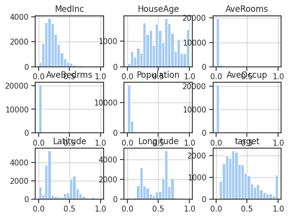

```python
df2.hist(bins=20)
```

### Statistical methods

```python
import numpy as np
import pandas as pd
np.set_printoptions(suppress=True)
pt = np.get_printoptions()['threshold']

from sklearn.datasets import load_breast_cancer
bc_data = load_breast_cancer()
# print(bc_data.DESCR)
```

```python
bc_features = pd.DataFrame(bc_data.data, columns=bc_data.feature_names)
bc_classes = pd.DataFrame(bc_data.target, columns=['IsMalignant'])

# build featureset and response class labels
bc_X = np.array(bc_features)
bc_y = np.array(bc_classes).T[0]
print('Feature set shape:', bc_X.shape)
print('Response class shape:', bc_y.shape)

# We can clearly see that there are a total of 30 features in this dataset
# and a total of 569 rows of observations.
```

```
Feature set shape: (569, 30)
Response class shape: (569,)
```

```python
#To get some more detail into the feature names and take a peek at the data points, you can use the following code.
# np.set_printoptions(threshold=30)
print('Feature set data [shape: '+str(bc_X.shape)+']')
print(np.round(bc_X, 2), '\n')
print('Feature names:')
print(np.array(bc_features.columns), '\n')
print('Response Class label data [shape: '+str(bc_y.shape)+']')
print(bc_y, '\n')
print('Response variable name:', np.array(bc_classes.columns))
np.set_printoptions(threshold=pt)
```

```
Feature set data [shape: (569, 30)]
[[ 17.99  10.38 122.8  ...   0.27   0.46   0.12]
 [ 20.57  17.77 132.9  ...   0.19   0.28   0.09]
 [ 19.69  21.25 130.   ...   0.24   0.36   0.09]
 ...
 [ 16.6   28.08 108.3  ...   0.14   0.22   0.08]
 [ 20.6   29.33 140.1  ...   0.26   0.41   0.12]
 [  7.76  24.54  47.92 ...   0.     0.29   0.07]]

Feature names:
['mean radius' 'mean texture' 'mean perimeter' 'mean area'
 'mean smoothness' 'mean compactness' 'mean concavity'
 'mean concave points' 'mean symmetry' 'mean fractal dimension'
 'radius error' 'texture error' 'perimeter error' 'area error'
 'smoothness error' 'compactness error' 'concavity error'
 'concave points error' 'symmetry error' 'fractal dimension error'
 'worst radius' 'worst texture' 'worst perimeter' 'worst area'
 'worst smoothness' 'worst compactness' 'worst concavity'
 'worst concave points' 'worst symmetry' 'worst fractal dimension']

Response Class label data [shape: (569,)]
[0 0 0 0 0 0 0 0 0 0 0 0 0 0 0 0 0 0 0 1 1 1 0 0 0 0 0 0 0 0 0 0 0 0 0 0 0
 1 0 0 0 0 0 0 0 0 1 0 1 1 1 1 1 0 0 1 0 0 1 1 1 1 0 1 0 0 1 1 1 1 0 1 0 0
 1 0 1 0 0 1 1 1 0 0 1 0 0 0 1 1 1 0 1 1 0 0 1 1 1 0 0 1 1 1 1 0 1 1 0 1 1
 1 1 1 1 1 1 0 0 0 1 0 0 1 1 1 0 0 1 0 1 0 0 1 0 0 1 1 0 1 1 0 1 1 1 1 0 1
 1 1 1 1 1 1 1 1 0 1 1 1 1 0 0 1 0 1 1 0 0 1 1 0 0 1 1 1 1 0 1 1 0 0 0 1 0
 1 0 1 1 1 0 1 1 0 0 1 0 0 0 0 1 0 0 0 1 0 1 0 1 1 0 1 0 0 0 0 1 1 0 0 1 1
 1 0 1 1 1 1 1 0 0 1 1 0 1 1 0 0 1 0 1 1 1 1 0 1 1 1 1 1 0 1 0 0 0 0 0 0 0
 0 0 0 0 0 0 0 1 1 1 1 1 1 0 1 0 1 1 0 1 1 0 1 0 0 1 1 1 1 1 1 1 1 1 1 1 1
 1 0 1 1 0 1 0 1 1 1 1 1 1 1 1 1 1 1 1 1 1 0 1 1 1 0 1 0 1 1 1 1 0 0 0 1 1
 1 1 0 1 0 1 0 1 1 1 0 1 1 1 1 1 1 1 0 0 0 1 1 1 1 1 1 1 1 1 1 1 0 0 1 0 0
 0 1 0 0 1 1 1 1 1 0 1 1 1 1 1 0 1 1 1 0 1 1 0 0 1 1 1 1 1 1 0 1 1 1 1 1 1
 1 0 1 1 1 1 1 0 1 1 0 1 1 1 1 1 1 1 1 1 1 1 1 0 1 0 0 1 0 1 1 1 1 1 0 1 1
 0 1 0 1 1 0 1 0 1 1 1 1 1 1 1 1 0 0 1 1 1 1 1 1 0 1 1 1 1 1 1 1 1 1 1 0 1
 1 1 1 1 1 1 0 1 0 1 1 0 1 1 1 1 1 0 0 1 0 1 0 1 1 1 1 1 0 1 1 0 1 0 1 0 0
 1 1 1 0 1 1 1 1 1 1 1 1 1 1 1 0 1 0 0 1 1 1 1 1 1 1 1 1 1 1 1 1 1 1 1 1 1
 1 1 1 1 1 1 1 0 0 0 0 0 0 1]

Response variable name: ['IsMalignant']
```